# Techniques de l'IA - TD2 Analyse

22 septembre 2025 - Thanh Lam DANG

## 0. Importation des librairies

Ci-dessous vous importerez les librairies dont vous aurez besoins :

```python
import pandas as pd
import numpy as np
import seaborn as sns
import matplotlib.pyplot as plt
import scipy.stats as stats
from sklearn.decomposition import FactorAnalysis, PCA
from factor_analyzer import FactorAnalyzer
from factor_analyzer.factor_analyzer import calculate_bartlett_sphericity
```

## 1. Validation et pré-traitement des données

Vous récupérerez des données sous format d'un ou plusieurs fichiers .csv et les lirez. Le jeu de données choisi comme exemple est BikeSharing. Les attributs catégoriels choisis pour l'ACF sont `season` et `weathersit`.

```python
df = pd.read_csv("bike_sharing_day.csv")
dict_season = {1:"winter", 2:"spring", 3:"summer", 4:"fall"}
dict_weather = {1: "Clear", 2: "Cloudy", 3: "Light Rain", 4: "Heavy Rain"}
humidity_bins = [0, 0.3, 0.5, 0.7, 0.9, 1]
humidity_labels = ['low', 'medium low', 'medium', 'high', 'extremely high']
df['humidity'] = pd.cut(df['hum'], humidity_bins, labels=humidity_labels)
df.replace({"season": dict_season, "weathersit": dict_weather}, inplace=True)
df.head()
```

|  | instant | dteday | season | yr | mnth | holiday | weekday | workingday | weathersit | temp | atemp | hum | windspeed | casual | registered | cnt | humidity |
| --- | --- | --- | --- | --- | --- | --- | --- | --- | --- | --- | --- | --- | --- | --- | --- | --- | --- |
| 0 | 1 | 2011-01-01 | winter | 0 | 1 | 0 | 6 | 0 | Cloudy | 0.344167 | 0.363625 | 0.805833 | 0.160446 | 331 | 654 | 985 | high |
| 1 | 2 | 2011-01-02 | winter | 0 | 1 | 0 | 0 | 0 | Cloudy | 0.363478 | 0.353739 | 0.696087 | 0.248539 | 131 | 670 | 801 | medium |
| 2 | 3 | 2011-01-03 | winter | 0 | 1 | 0 | 1 | 1 | Clear | 0.196364 | 0.189405 | 0.437273 | 0.248309 | 120 | 1229 | 1349 | medium low |
| 3 | 4 | 2011-01-04 | winter | 0 | 1 | 0 | 2 | 1 | Clear | 0.200000 | 0.212122 | 0.590435 | 0.160296 | 108 | 1454 | 1562 | medium |
| 4 | 5 | 2011-01-05 | winter | 0 | 1 | 0 | 3 | 1 | Clear | 0.226957 | 0.229270 | 0.436957 | 0.186900 | 82 | 1518 | 1600 | medium low |

## 2. Analyse Factorielle des Correspondance

Afin de réaliser l'analyse factorielle des correspondance vous commencerez par créer un tableau de contingence entre les deux variables catégorielles.

```python
# Tableau de contingence
tab_contingence = pd.crosstab(df["weathersit"], df["season"])
print(tab_contingence)
```

```
season      fall  spring  summer  winter
weathersit
Clear        103     113     136     111
Cloudy        65      68      48      66
Light Rain    10       3       4       4
```

```python
# Standardisation
temp = tab_contingence.sub(tab_contingence.mean())
X_scaled = temp.div(tab_contingence.std())
#print(X_scaled)
```

Nous allons maintenant nous assurer qu'il est pertinent de réaliser une AFC sur ces données. Pour ce faire nous faisons le test suivant :test de sphéricité de Bartlett (Bartlett Sphericity Test en anglais). Ce test vérifie les intercorrelations entre les variables en faisant la comparaison entre la matrice de corrélation et la matrice identité. Si les variables sont indépendantes, la matrice de corrélation est égale à la matrice identité. Afin de pouvoir réaliser une AFC, il est nécessaire que les variables soient globalement dépendantes, i.e., que la matrice de corrélation et la matrice d'identité ne soient pas les mêmes. Il faut pour cela que la p-value du test soit le plus proche possible de 0.

```python
_, p_val = calculate_bartlett_sphericity(tab_contingence)
_, p_val_std = calculate_bartlett_sphericity(X_scaled)
print("p-val avec standardisation: ", p_val_std, "\np-val sans std: ", p_val)
```

```
p-val avec standardisation:  1.0
p-val sans std:  1.0
```

Ici la p-valeur est plus grande que 0.05. Nous ne pouvons rejeter l'hypothèse que deux variables `season` et `weathersit` sont indépendantes.

```python
tab_contingence = pd.crosstab(df["season"], df["humidity"])
print(tab_contingence)
```

```
humidity  low  medium low  medium  high  extremely high
season
fall        0          17      93    57              11
spring      3          43      75    61               2
summer      0          28     104    53               3
winter      1          54      81    41               3
```

```python
# Standardisation
temp = tab_contingence.sub(tab_contingence.mean())
X_scaled = temp.div(tab_contingence.std())
X2_val, p_val = calculate_bartlett_sphericity(X_scaled)
print(X2_val, p_val)
```

```
nan nan
```

La p-val est NaN, pour l'une des causes suivantes: https://stackoverflow.com/questions/65092892/calculate-bartlett-sphericity-test-outputing-nan-values

```python
# An alternative to bartlette_sphericity
from scipy.stats import chi2_contingency
chi2, pval, dof, expected = chi2_contingency(tab_contingence)
print(pval)
```

```
1.688667622804278e-06
```

Le test de contingence Chi2 montre que nous pouvons rejeter l'hypothèse nulle que deux variables sont indépendantes. L'ACF peut être réalisée.

A partir du moment où vos données sont valides pour une AFC, vous pouvez maintenant déterminer le nombre de facteurs à conserver pour votre analyse. Les facteurs, les variables latentes, sont des combinaisons linéaires des points modalités (lignes ou colonnes) exprimés par des profils (lignes ou colonnes). Le nombre maximal de facteurs est égal au minimum du nombre de lignes et de colonnes -1.

```python
tab_contingence.shape
n_facteurs_max = min(tab_contingence.shape[0] - 1, tab_contingence.shape[1] - 1)
```

Nous commencerons par réaliser une première analyse sans rotation afin de déterminer le nombre de facteurs à fixer pour l’analyse.

```python
print(X_scaled)
```

```
humidity       low  medium low    medium     high  extremely high
season
fall     -0.707107   -1.135019  0.368394  0.46291        1.490491
spring    1.414214    0.460143 -1.027626  0.92582       -0.655816
summer   -0.707107   -0.460143  1.221518  0.00000       -0.417338
winter    0.000000    1.135019 -0.562286 -1.38873       -0.417338
```

```python
fa = FactorAnalyzer(n_factors = n_facteurs_max, rotation = None)
fa.fit(X_scaled)
ev, v = fa.get_eigenvalues()
fa_res = fa.loadings_
print(fa_res)
```

```
[[-0.84715318  0.52856634  0.02733875]
 [-0.92829107 -0.36422837 -0.06042317]
 [ 0.83865903 -0.30145568  0.45013202]
 [ 0.21332043  0.94617565  0.23582356]
 [ 0.77293074  0.20784094 -0.59609925]]
```

```python
fa_new = FactorAnalysis(n_components=n_facteurs_max, random_state=0)
X_transformed = fa_new.fit_transform(X_scaled)
print(fa_new.components_)
```

```
[[-0.73428282 -0.80461031  0.72692039  0.1848987   0.6699494 ]
 [-0.45854515  0.31597765  0.2615207  -0.82083216 -0.18030746]
 [ 0.02377164 -0.05253927  0.39139964  0.20505375 -0.51832135]]
```

```python
columns = ["col_" + str(i + 1) for i in range(n_facteurs_max)]
df_factors = pd.DataFrame(fa.loadings_, columns= columns, index = X_scaled.columns)
df_factors.head()
```

| humidity | col_1 | col_2 | col_3 |
| --- | --- | --- | --- |
| low | -0.847153 | 0.528566 | 0.027339 |
| medium low | -0.928291 | -0.364228 | -0.060423 |
| medium | 0.838659 | -0.301456 | 0.450132 |
| high | 0.213320 | 0.946176 | 0.235824 |
| extremely high | 0.772931 | 0.207841 | -0.596099 |

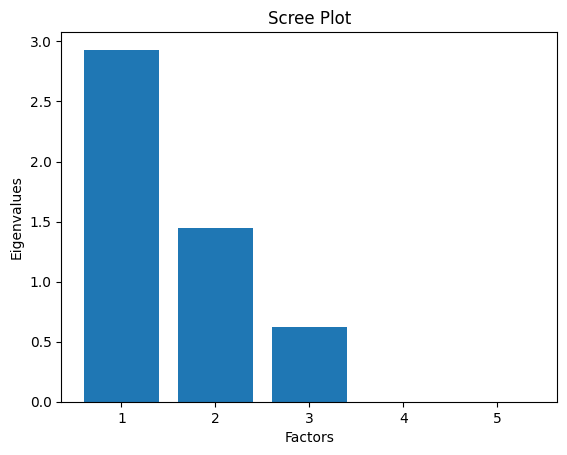

```python
# Visualisation des facteurs
fig, ax = plt.subplots()
labels = [str(i+1).zfill(1) for i in range(len(ev))]
ax.bar(labels, ev, label = labels)
ax.set_xlabel("Factors")
ax.set_ylabel("Eigenvalues")
plt.title("Scree Plot")
plt.show()
```

Nous afficherons les AFC en fonctions de 3 rotations différentes, les représentations graphiques seront donc légèrement différentes.

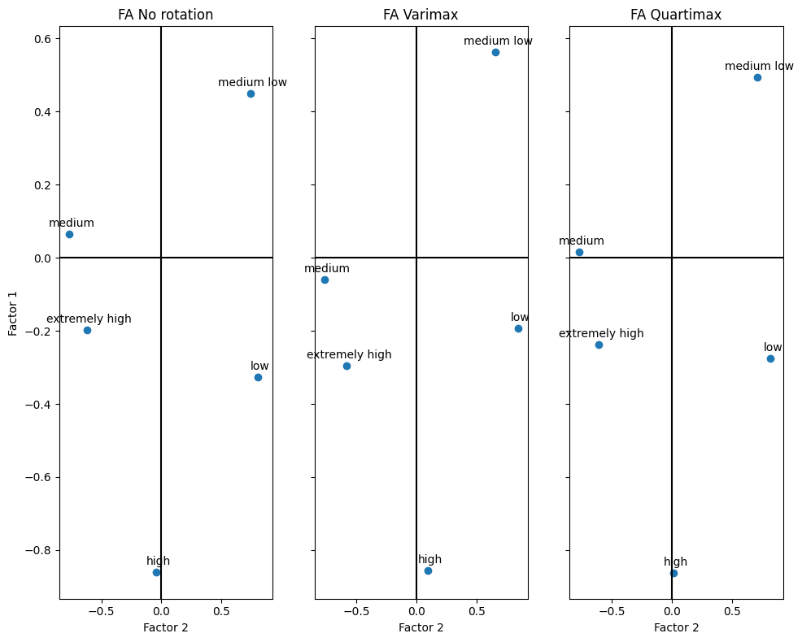

```python
# Utiliser FactorAnalysis de scikitlearn
methods = [
    ("FA No rotation", FactorAnalysis(2,)),
    ("FA Varimax", FactorAnalysis(2, rotation="varimax")),
    ("FA Quartimax", FactorAnalysis(2, rotation="quartimax")),
]
fig, axes = plt.subplots(ncols=3, figsize=(10, 8), sharex=True, sharey=True)

for ax, (method, fa) in zip(axes, methods):
    fa = fa.fit(X_scaled)

    components = fa.components_
    ax.scatter(components[0,:], components[1, :])
    ax.axhline(0, -1, 1, color='k')
    ax.axvline(0, -1, 1, color='k')
    for i,j, z in zip(components[0, :], components[1, :], X_scaled.columns):
        ax.text(i+.02, j+.02, str(z), ha="center")
    ax.set_title(str(method))
    if ax.get_subplotspec().is_first_col():
        ax.set_ylabel("Factor 1")
    ax.set_xlabel("Factor 2")

plt.tight_layout()
plt.show()
```

Questions:

- Quelles sont les variables corrélées ?
- A partir de ces corrélations, pourriez-vous trouver le sens de chaque facteur ?

## 3. Analyse des Correspondance Multiples (ACM)

Afin de procéder à cette analyse un pré-traitement sur les variables est de nouveau requis. Commencez par sélectionner l'ensemble des variables qualitatives de votre choix puis transformez votre dataframe en un tableau disjonctif complet

```python
dc = pd.DataFrame(pd.get_dummies(df[["weathersit","season", "humidity"]]))
dc.head()
```

|  | weathersit_Clear | weathersit_Cloudy | weathersit_Light Rain | season_fall | season_spring | season_summer | season_winter | humidity_low | humidity_medium low | humidity_medium | humidity_high | humidity_extremely high |
| --- | --- | --- | --- | --- | --- | --- | --- | --- | --- | --- | --- | --- |
| 0 | False | True | False | False | False | False | True | False | False | False | True | False |
| 1 | False | True | False | False | False | False | True | False | False | True | False | False |
| 2 | True | False | False | False | False | False | True | False | True | False | False | False |
| 3 | True | False | False | False | False | False | True | False | False | True | False | False |
| 4 | True | False | False | False | False | False | True | False | True | False | False | False |